# Effects of time and user information on trips duration

## Investigation Overview

In this investigation, I wanted to look at these features and see how it affect the trips duration. The main focus will be on the time information and the user information

## Dataset Overview

This data set includes information about individual rides made in a bike-sharing system covering the greater San Francisco Bay area. The columns have information about trip duration, member information, time information, and station information.

## Trips Duration Distribution

Most trips take less than 30 minutes.

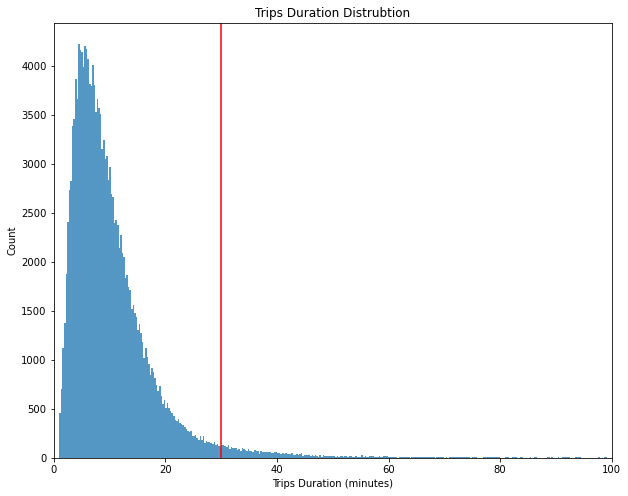

## Duration vs. Age

The relationship between trip duration and members' age is negative. And this makes sense since older members can't ride for a long time.

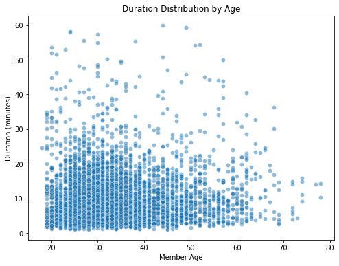

## Duration by User Type and Start Time of Day

Customers go on consistently long trips duration than subscribers at all times during the day. Customers' trips are long at midnight, and especially at midday.

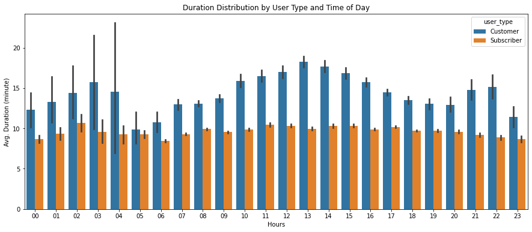

## Duration by User Type and Days of the Week

The trips duration for subscribers is consistent across all the days of the week whereas, the trip's duration increases for customers on the weekends.

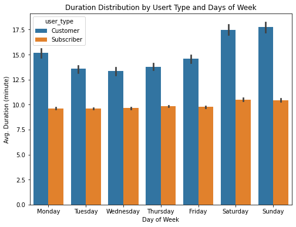

## Duration by Gender and User Type

Whether females are subscribers or customers, they go on long-duration trips than males.

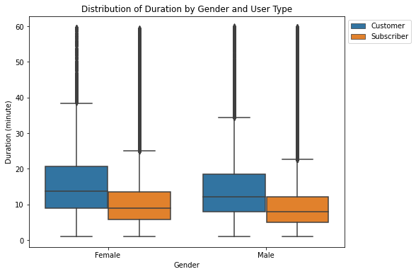

## Age by User Type and Gender

Now, we can see the reason why females go on longer duration trips than males. This is because females are younger than males, and we saw before that the relationship between duration and ages is negative. \ The median ages for females, and males whether they are customers, or subscribers are consistent.

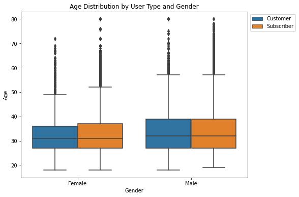